# Statistical Inference - Assignment part 1

Christopher Lovell

Wednesday, January 21, 2015

# Statistical Inference Course Project - Part 1

In this project we re going to cimluate the exponential distribution, and use the results to compare the properties of the sample and underlying distributions.

## Set Up

First we need to set up our environment. We load the ggplot2 library for doing our visualisations, and initialise our random seed so that our results are consistent on repeat.

```r
if(!require(ggplot2)){
  install.packages("ggplot2")
}
set.seed(1)
```

## Simulations

First we initialise lambda and our simulation values, where `N` is the total number of simulations, and `n` is the sample size.

```r
lambda=0.2
N=1000
n=40
```

We can then create an `N*n` matrix of our simulation results.

```r
data<-matrix(rexp(N*n,lambda), N)
```

## Sample Mean versus Theoretical Mean

The theoretical mean is given by $\mu=1/\lambda$.

```r
mean = 1/lambda
```

We can compare this to the sample mean, taken by averaging the samples in a given simulation, then averaging over all simulations.

```r
sample_mean = mean(apply(data,1,function(x) mean(x)))
```

The theoretical mean is 5, which is close to the sample mean 4.9900252.

We can also plot the distribution of sample means, and compare to the theoretical mean shown in red.

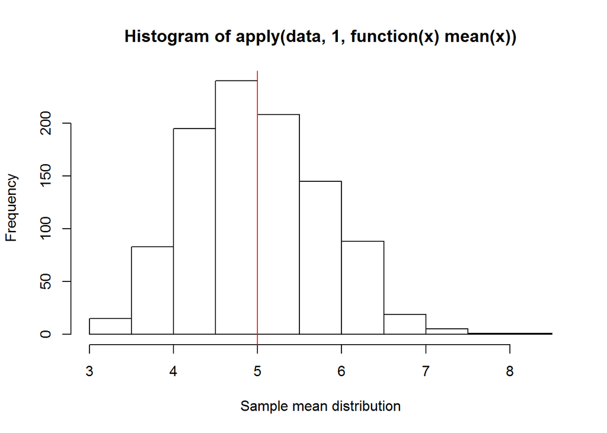

```r
hist(apply(data,1,function(x) mean(x)),xlab = "Sample mean distribution")
abline(v=mean,col="red")
```

The centre of the distribution alines with the theoretical mean.

```r
sd = (1/lambda)/(n^0.5)
```

```r
sd = (1/lambda)/(n^0.5)
# variance of the sample
sample_var<-apply(data,1,function(x) sum((x-mean(x))^2)/(n-1))
sd^2
```

```
## [1] 0.625
```

## Distribution

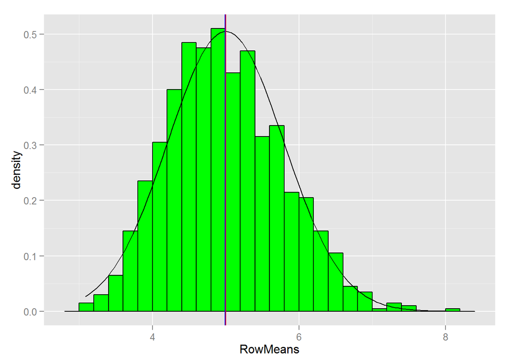

```r
#random_observations<-unlist(data)[1:N]
#hist(random_observations,breaks=seq(from = 0,to = 40,by = 1))

rowmeans<-as.data.frame(apply(data,1,function(x) mean(x)),row.names="RowMeans")
names(rowmeans)<-"RowMeans"

# histogram of 1000 averages of 40 random variables
cp<-ggplot(rowmeans,aes(x=RowMeans))
cp<-cp+geom_histogram(binwidth = lambda,fill="green",color="black",aes(y = ..density..))
cp<-cp+stat_function(fun=dnorm,args=list(mean=mean,sd=sd))
cp<-cp+geom_vline(xintercept=mean,color="red")
cp<-cp+geom_vline(xintercept=sample_mean,color="blue")
cp
```

```r
#ci <- mean + (c(-1,1)*1.96*sd/n)
#sample_ci <- sample_mean + (c(-1,1)*1.96*sample_sd/n)
```